# Factors influencing students PISA scores

## Investigation Overview

The purpose of this research is to inquire the essential factors that have the greatest effect on the grade of students on the assessment taken. The main factors that were considered were family structure, behavioural factors, social status, gender, immigration, country of residence e.t.c

## Dataset Overview

PISA is a survey of students' skills and knowledge as they approach the end of compulsory education. This survey examines how well students have learned the school curriculum, how well prepared they are for life beyond school. Around 510,000 students in 65 economies took part in the PISA 2012 assessment of reading, mathematics and science. Of those economies, 44 took part in an assessment of creative problem solving and 18 in an assessment of financial literacy.

```python
# import all packages and set plots to be embedded inline
import numpy as np
import pandas as pd
import matplotlib.pyplot as plt
import seaborn as sb

%matplotlib inline

# suppress warnings from final output
import warnings
warnings.simplefilter("ignore")
```

```python
# load in the dataset into the pandas data frame
df = pd.read_csv('pisa_cleaned.csv')
```

```python
df.head()
```

|  | country | gender | age | immigration_status | international_home_language | family_structure | highest_parents_education | home_educational_resources | wealth | home_possessions | ... | language_learning_time | math_learning_time | science_learning_time | maths_anxiety | att_tow_sch_act | teacher_stu_rel | maths_score | reading_score | science_score | total_score |
| --- | --- | --- | --- | --- | --- | --- | --- | --- | --- | --- | --- | --- | --- | --- | --- | --- | --- | --- | --- | --- | --- |
| 0 | Albania | Female | 16.17 | Native | Language of the test | 2.0 | ISCED 3A, ISCED 4 | -1.29 | -2.92 | -2.61 | ... | NaN | NaN | NaN | 0.32 | 0.5206 | -1.04 | 366.18634 | 261.01424 | 371.91348 | 999.11406 |
| 1 | Albania | Female | 16.17 | Native | Language of the test | 2.0 | ISCED 5A, 6 | 1.12 | 0.69 | 1.41 | ... | 315.0 | 270.0 | 90.0 | NaN | NaN | NaN | 470.56396 | 384.68832 | 478.12382 | 1333.37610 |
| 2 | Albania | Female | 15.58 | Native | Language of the test | 2.0 | ISCED 5A, 6 | -0.69 | -0.23 | 0.14 | ... | 300.0 | NaN | NaN | NaN | NaN | NaN | 505.53824 | 405.18154 | 486.60946 | 1397.32924 |
| 3 | Albania | Female | 15.67 | Native | Language of the test | 2.0 | ISCED 5A, 6 | 0.04 | -1.17 | -0.73 | ... | 135.0 | 135.0 | 90.0 | 0.31 | NaN | NaN | 449.45476 | 477.46376 | 453.97240 | 1380.89092 |
| 4 | Albania | Female | 15.50 | Native | Language of the test | 2.0 | ISCED 3A, ISCED 4 | -0.69 | -1.17 | -0.57 | ... | NaN | NaN | NaN | 1.02 | 1.2115 | -0.02 | 385.50398 | 256.01010 | 367.15778 | 1008.67186 |

5 rows × 29 columns

## Distribution of student's scores

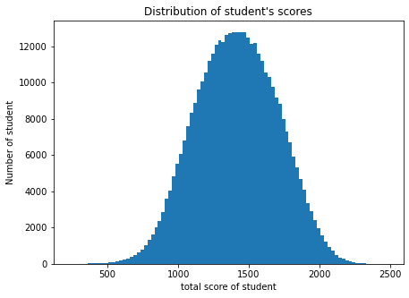

```python
# get the total score which is the sum of all the mean scores for each of the assessment taken
df['total_score'] = (df['maths_score'] + df['reading_score'] + df['science_score'])

# let's then check the distribution of the total score
bins = np.arange(min(df['total_score']),max(df['total_score'])+25,25)
fig = plt.figure(figsize=[7,5])
plt.hist(data = df, x='total_score', bins=bins)
plt.title("Distribution of student's scores")
plt.xlabel('total score of student')
plt.ylabel('Number of student');
```

## Distribution of parents education

```python
def count_plot(data, column, title, xlabel, ylabel):
    base_color = sb.color_palette()[0]
    type_order = data[column].value_counts().index
    n_edu = data[column].value_counts().sum()
    fig = plt.figure(figsize=(12,4))
    sb.countplot(data=data, x=column, color=base_color, order=type_order)
    plt.title(title)
    plt.xlabel(xlabel)
    plt.ylabel(ylabel);



    # Recalculating the type_counts just to have clarity.
    type_counts = data[column].value_counts()

    # get the current tick locations and labels
    locs, labels = plt.xticks()

    # loop through each pair of locations and labels
    for loc, label in zip(locs, labels):

        # get the text property for the label to get the correct count
        count = type_counts[label.get_text()]
        pct_string = '{:0.1f}%'.format(100*count/n_edu)

        # print the annotation just below the top of the bar
        plt.text(loc, count+200, pct_string, ha = 'center', color = 'black')
```

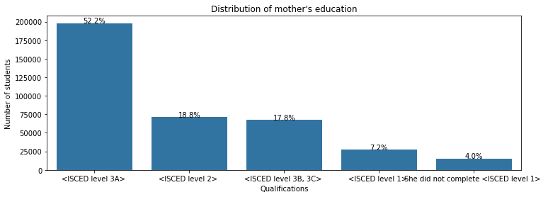

```python
title = "Distribution of mother's education"
xlabel = 'Qualifications'
ylabel = 'Number of students'

count_plot(df, 'mothers_education', title, xlabel, ylabel)
```

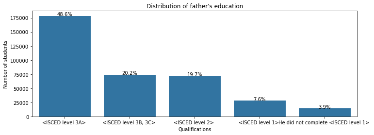

```python
title = "Distribution of father's education"
xlabel = 'Qualifications'
ylabel = 'Number of students'

count_plot(df, 'fathers_education', title, xlabel, ylabel)
```

```python
#Order categories of parent'seducation
parent_order = pd.api.types.CategoricalDtype(
                    categories=['None','ISCED 1','ISCED 2','ISCED 3B, C','ISCED 3A, ISCED 4','ISCED 5B','ISCED 5A, 6'],
                    ordered=True)
df['highest_parents_education'] = df['highest_parents_education'].astype(parent_order)
print(df.highest_parents_education.unique())
```

```
['ISCED 3A, ISCED 4', 'ISCED 5A, 6', 'ISCED 3B, C', 'ISCED 2', 'ISCED 5B', 'None', 'ISCED 1', NaN]
Categories (7, object): ['None' < 'ISCED 1' < 'ISCED 2' < 'ISCED 3B, C' < 'ISCED 3A, ISCED 4' < 'ISCED 5B' < 'ISCED 5A, 6']
```

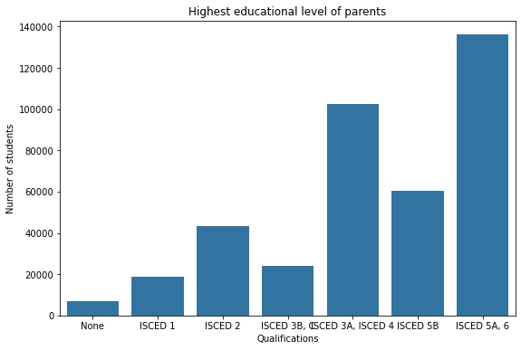

```python
#Highest educational level of parents
plt.figure(figsize=[9, 6])
base_color = sb.color_palette()[0]
sb.countplot(data = df, x = 'highest_parents_education', color = base_color)
plt.title('Highest educational level of parents')
plt.xlabel('Qualifications')
plt.ylabel('Number of students');
```

- As can be seen from the plot, more than 50% of the parents have at least a general upper secondary qualification.

## Correlation between the 3 score variables

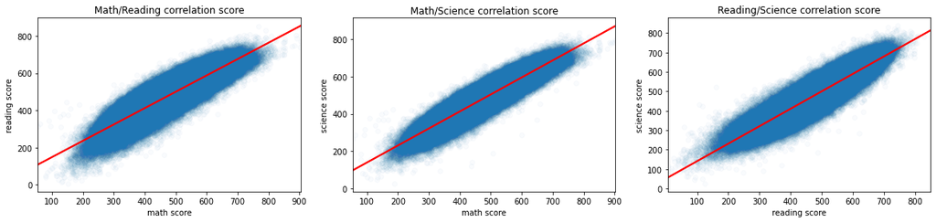

```python
# Define figure size for subplots
plt.figure(figsize = [20, 4])

# histogram on the left
# 1 row, 3 cols, subplot 1
ax1 = plt.subplot(1, 3, 1)
sb.regplot(data = df, x = 'maths_score', y = 'reading_score', scatter_kws={'alpha':1/40}, line_kws={"color": "red"});
plt.xlabel('math score')
plt.ylabel('reading score')
ax1.set_title("Math/Reading correlation score");

# histogram in the middle
# 1 row, 3 cols, subplot 2
ax2 = plt.subplot(1, 3, 2)
sb.regplot(data = df, x = 'maths_score', y = 'science_score', scatter_kws={'alpha':1/40}, line_kws={"color": "red"});
plt.xlabel('math score')
plt.ylabel('science score')
ax2.set_title("Math/Science correlation score");

# histogram on the right
# 1 row, 3 cols, subplot 3
ax3 = plt.subplot(1, 3, 3)
sb.regplot(data = df, x = 'reading_score', y = 'science_score', scatter_kws={'alpha':1/40}, line_kws={"color": "red"});
plt.xlabel('reading score')
plt.ylabel('science score')
ax3.set_title("Reading/Science correlation score");
```

- As can be seen on the graph, the positive correlation shows that the higher a student's maths score, the higher the science scores and vice versa.
- the positive correlation shows that the higher a student's maths score, the higher the reading scores and vice versa.
- the positive correlation shows that the higher a student's science score, the higher the science scores and vice versa.
- This correlation is slightly weaker between math and reading scores, as seen by the more disperse pattern of the scatterplot on the left.

## Maths, reading, science average scores based on countries

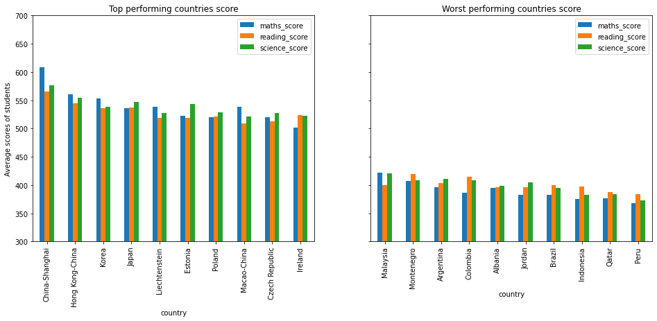

```python
df_countries = df.groupby('country')[['maths_score','reading_score','science_score','total_score']].mean()

# top performing countries based on total scores
top_country = df_countries.sort_values(by='total_score', ascending=False).head(10).iloc[:,:-1]

# least performing countries based on total score
bottom_country = df_countries.sort_values(by='total_score', ascending=False).tail(10).iloc[:,:-1]

f,axes = plt.subplots(1,2, figsize=(16,6), sharey=True)
top_country.plot(kind='bar',ax=axes[0])
bottom_country.plot(kind='bar',ax=axes[1]);
axes[0].set_title('Top performing countries score');
axes[1].set_title('Worst performing countries score')
axes[0].set_ylabel('Average scores of students')
plt.ylim(300,700);
```

- As can be seen above, 50% of the top performers are students from Asia which is quite understandable due to the high level and quality of education over there. the other 50% being Europian countries.
- Countries coming at the bottom mainly from South America and middle east with Peru coming last.

## Checking the effect of the behavioural and psychological factors on the scores of the students

```python
#Family structure: Change labels
df['family_structure'] = df['family_structure'].map({1.0: "Single parent", 2.0: "Two parents", 3.0: "No parents"})
```

```python
#Order categories of perceived control
preceived = pd.api.types.CategoricalDtype(
                    categories=['Strongly disagree','Disagree','Agree','Strongly agree'],
                    ordered=True)
df['perceived_control'] = df['perceived_control'].astype(preceived)
```

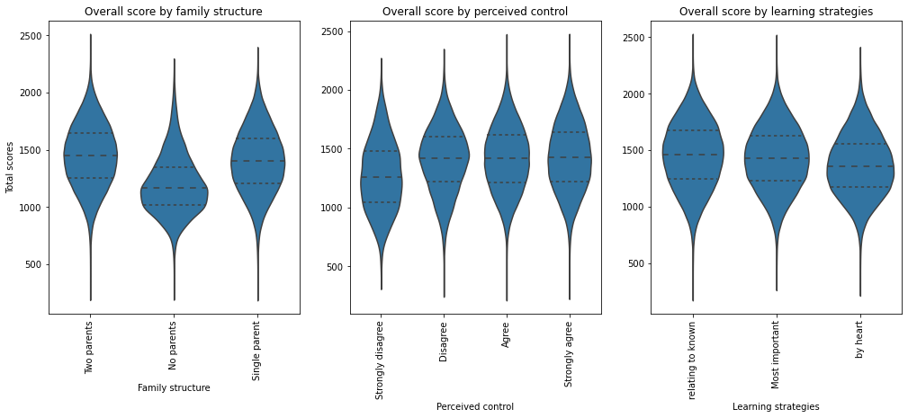

```python
plt.figure(figsize = [17, 6])

plt.subplot(1, 3, 1)
sb.violinplot(data = df, x = 'family_structure', y = 'total_score', color = base_color,
              inner="quartile").set(xlabel = 'Family structure', ylabel = 'Total scores')
plt.title('Overall score by family structure')
plt.xticks(rotation=90);

plt.subplot(1, 3, 2)
sb.violinplot(data = df, x = 'perceived_control', y = 'total_score', color = base_color,
              inner="quartile").set(xlabel = 'Perceived control', ylabel = None)
plt.title('Overall score by perceived control')
plt.xticks(rotation=90);


plt.subplot(1, 3, 3)
sb.violinplot(data = df, x = 'learning_strategies', y = 'total_score', color = base_color,
              inner="quartile").set(xlabel = 'Learning strategies', ylabel = None)
plt.title('Overall score by learning strategies')
plt.xticks(rotation=90);
```

## Checking the effects of parents education on the scores of students

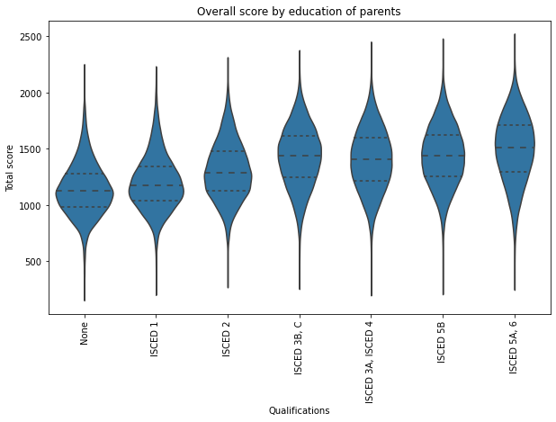

```python
# let's check the effect of the parents education first
plt.figure(figsize = [10, 6])
sb.violinplot(data = df, x = 'highest_parents_education', y = 'total_score', color = base_color,
              inner="quartile").set(xlabel = 'Qualifications', ylabel = 'Total score')
plt.title('Overall score by education of parents')
plt.xticks(rotation=90);
```

- Just as expected, there is a positive correlation between the educational level of the parents and the scores of the students i.e the higher the level of education, the higher the score and vice vesa.

## Scores per gender in each country

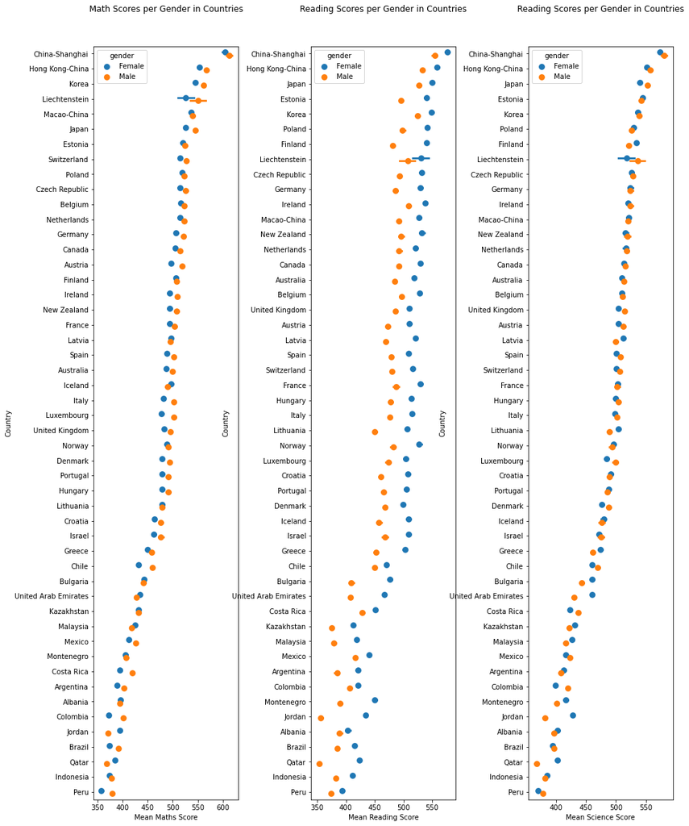

```python
# using pointplot subplots, plot each country against the mean scores, with gender in 'hue'
maths = df.groupby('country')['maths_score'].mean().sort_values(ascending = False).index
reading = df.groupby('country')['science_score'].mean().sort_values(ascending = False).index
science = df.groupby('country')['science_score'].mean().sort_values(ascending = False).index

#plot
plt.figure(figsize = [15, 20])
plt.subplots_adjust(wspace = 0.5)

plt.subplot(1,3,1)
ax = sb.pointplot(data = df, x= 'maths_score', y = 'country', hue = 'gender', dodge = 0.2,
                  linestyles = "", order = maths)
plt.ylabel('Country')
plt.xlabel('Mean Maths Score')
plt.title('Math Scores per Gender in Countries', y =1.04)

plt.subplot(1,3,2)
ax = sb.pointplot(data = df, x= 'reading_score', y = 'country', hue = 'gender', dodge = 0.2,
                  linestyles = "", order = reading)
plt.ylabel('Country')
plt.xlabel('Mean Reading Score')
plt.title('Reading Scores per Gender in Countries', y =1.04)

plt.subplot(1,3,3)
ax = sb.pointplot(data = df, x= 'science_score', y = 'country', hue = 'gender', dodge = 0.2,
                  linestyles = "", order = reading)
plt.ylabel('Country')
plt.xlabel('Mean Science Score')
plt.title('Reading Scores per Gender in Countries', y =1.04)
```

### Total score and parents education with respect to social class and immigration status

```python
# getting a variable to rate possessions
#Create a new variable of social class
df.loc[(df['home_possessions'] < -0.9), 'social_class'] = 'low'
df.loc[(df['home_possessions'] > -0.9) & (df['home_possessions'] <= 0.5), 'social_class'] = 'middle'
df.loc[(df['home_possessions'] > 0.5), 'social_class'] = 'high'

#Order categories of social class
social_order = pd.api.types.CategoricalDtype(
                    categories=['low','middle','high'], ordered=True)
df['social_class'] = df['social_class'].astype(social_order)
print(df.social_class.unique())
```

```
['low', 'high', 'middle', NaN]
Categories (3, object): ['low' < 'middle' < 'high']
```

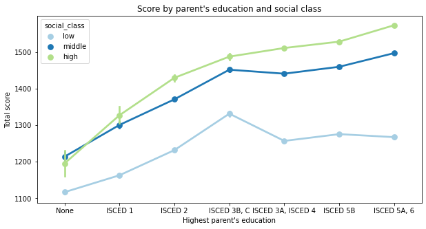

```python
plt.figure(figsize = [10, 5])
sb.pointplot(data = df, x = 'highest_parents_education', y = 'total_score', hue = 'social_class', palette = "Paired")
plt.xlabel("Highest parent's education")
plt.ylabel('Total score')
plt.title("Score by parent's education and social class");
```

NB: Social class measures the number of belongings at home

- A higher level of Education by the parents leads to a better score for the student. As can be seen on the graph, the students having parents with the highest level of education and highest possession(high social class) have the highest scores and vice versa.
- It can also be seen that in the lower social class, the maximum grade peak is reached with a parental education of ISCED 3B, 4.

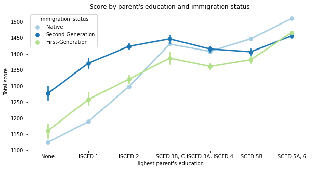

```python
plt.figure(figsize = [10, 5])
sb.pointplot(data = df, x = 'highest_parents_education', y = 'total_score', hue = 'immigration_status', palette = "Paired")
plt.xlabel("Highest parent's education")
plt.ylabel('Total score')
plt.title("Score by parent's education and immigration status");
```

- Although the impact of parent's educational background is positively correlated to student's grades, it is more noticable in families with native-born parents. In the case of parents with an educational level up to ISCED 2, students with second-generation immigrant parents show better test scores while students having parents with highest qualification and native-born have the highest scores.

## Total score with respect to perceived control and learning strategies

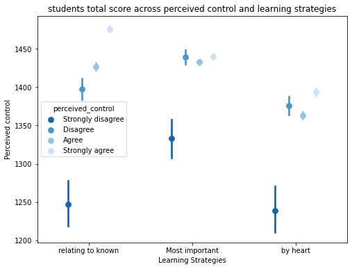

```python
fig = plt.figure(figsize = [8,6])
ax = sb.pointplot(data = df, x = 'learning_strategies', y = 'total_score', hue = 'perceived_control',
         palette = 'Blues_r', linestyles = '', dodge = 0.4)
plt.title('students total score across perceived control and learning strategies')
plt.xlabel('Learning Strategies')
plt.ylabel('Perceived control')
ax.set_yticklabels([],minor = True)
plt.show();
```

NB : perceived control shows to what extent does the student identify with the statement "I can succeed with enough effort".

- Across every learning strategy, strongly disagreeing with the statement above will lead to a lower score compared to other options regardless of the learning strategy while the reverse is the case with the students who strongly believe in success inherent from inputing enough effort.
- students that learn by means of relating new concepts to existing ones and strongly agree with the statement above most usually will have the highest scores.
- As seen in earlier representation that the most effective learning strategy is relating new concepts to existing, applying this strategy and disagreeing with the statement above will lead to lower scores.

```python
!jupyter nbconvert "pisa_explanation.ipynb" --to slides --post serve --no-input --no-prompt
```